# R Notebook

R Notebook creado para realizar el calculo del IPP para el año 2024

```r
library("readxl")
library("tidyverse")
require("tidyverse")
library("writexl")
library("tibble")
library("openxlsx")
library("DBI")
library("odbc")
library("RSQLite")
library("psych")
library("pracma")
library("bit64")
library('glue')
library('RMySQL')
library('stringi')
library('rlang')
library('ggplot2')

source("funciones.R")
#source("func_test.R") #este archivo tiene el borrador de las funciones que se utilizan en el script
```

## 1. Calculo del IPP

Ingresa el numero correspondiente al mes que se va a calcular (por el momento no se toma en cuenta el año ya que se esta empezando con el año 2024)

```r
mes <- 3
```

```r
variables <- inputdata(mes)

mes <- variables$mes
mesant <- variables$mes_ant
months <- variables$months
rows <- variables$rows

mes
```

```
[1] "MARZO"
```

```r
mesant
```

```
[1] "FEBRERO"
```

```r
months
```

```
[1] "ENERO"   "FEBRERO" "MARZO"
```

```r
rows
```

```
[1] 1 2 3
```

Se importan las ponderaciones y se modifican los strings de los codigos para su uso dentro del script

```r
ponderaciones <- read_excel("catalogoIPP_test.xlsx", sheet = "Sheet2") %>%
  mutate(VARIEDAD = gsub("\\.", "", VARIEDAD)) %>%
  rename(PRODUCTO = VARIEDAD, ponderacion = `Ponderacion 5 Digitos`) %>%
  mutate(
    ACTIVIDAD = substr(PRODUCTO, 1, 6),
    CLASE = substr(PRODUCTO, 1, 5),
    GRUPO = substr(PRODUCTO, 1, 4),
    DIVISION = substr(PRODUCTO, 1, 3),
    SECCION = substr(PRODUCTO, 1, 1))
```

Se importan los indices del mes anterior

```r
file_name <- paste0("indices/ind_", mesant, ".xlsx")
indant <- read_excel(file_name, sheet = "Sheet1") %>%
  mutate(PRODUCTO = gsub("\\.", "", PRODUCTO))
```

Se importan los precios actuales

```r
precios <- read_excel("precios_test.xlsx", sheet = "Sheet1") %>%
  mutate(ACTIVIDAD = gsub("\\.", "", ACTIVIDAD),
         PRODUCTO = gsub("\\.", "", PRODUCTO),
         VARIEDAD = gsub("\\.", "", VARIEDAD))

bol <- precios %>%
  select(PRODUCTO, VARIEDAD, all_of(mes), all_of(mesant)) %>%
  filter(!!sym(mes) != 0) #se quitan los datos que en el mes actual son cero para imputarlos
```

### 1.1 Imputación de precios

Realiza la imputación de los precios faltantes y se obtiene un dataframe con todos los precios incluyendo los imputados.

```r
boleta <- imputacion()
```

### 1.2 Calculo del indice

Calcula el relativo de los precios de las variedades

```r
relativo_var <- boleta %>%
  mutate(rel_var = !!sym(mes) / !!sym(mesant)) %>%
  mutate(rel_var = if_else(is.infinite(rel_var) | is.nan(rel_var) | is.na(rel_var), 1, rel_var)) %>%
  drop_na(PRODUCTO)
```

Revisa los valores de los relativos calculados, esto para determinar si hay valores que pueden impactar el calculo de los indices

```r
relativo_var %>% filter(rel_var > 2 | rel_var == 0)
```

| PRODUCTO | VARIEDAD | MARZO | FEBRERO | rel_var |
| --- | --- | --- | --- | --- |
| C210011 | C21001106 | 10 | 1.00000 | 10 |
| C221911 | C22191101 | 0 | 81.01000 | 0 |
| C120011 | C12001101 | 0 | 62.77000 | 0 |
| C120011 | C12001101 | 0 | 3.12000 | 0 |
| C120011 | C12001101 | 0 | 2.34000 | 0 |
| C104013 | C10401301 | 0 | 220.54000 | 0 |
| C102012 | C10201201 | 0 | 20.53600 | 0 |
| C102012 | C10201201 | 0 | 27.09678 | 0 |

Calcula la media geométrica de los relativos de los precios de las variedades

```r
ind_var <- relativo_var %>% group_by(PRODUCTO) %>%
  summarize(rel_prod = geometric.mean(rel_var))
```

Calcula el indice a nivel de productos, creando además un dataframe con las decripciones de los productos para agregarlas al resultados de los indices calculados

```r
ind_prod <- ind_var %>% left_join(indant %>% select(PRODUCTO, indice), by = join_by(PRODUCTO)) %>%
  rename(indant = indice) %>%
  mutate(indice = indant*rel_prod)

descrip <- ponderaciones %>% filter(CCP...1 == 'PRODUCTO') %>%
    select(PRODUCTO, DESCRIPCION, ponderacion)

ind_prod01 <- ind_prod %>% select(PRODUCTO, indice) %>% left_join(descrip, by = join_by(PRODUCTO)) %>%
    select(PRODUCTO, DESCRIPCION, everything())
```

Calcula los indices de los niveles superiores utilizando la funcion ‘calc_indx’

```r
ind_act <- calc_indx(ACTIVIDAD)
ind_clase <- calc_indx(CLASE)
ind_grupo <- calc_indx(GRUPO)
ind_div <- calc_indx(DIVISION)
calc_indx(SECCION) #este seria el indice general
```

| SECCION | DESCRIPCION | sum1 | ponderacion | indice |
| --- | --- | --- | --- | --- |
| C | Industria de Manufactura | 9067.287 | 95.36888 | 95.07595 |

```r
ind <- calc_indx(SECCION)
```

### 1.3 Determinacion de precios faltantes

Se buscan los precios faltantes en la boleta, separandolos en dos grupos: los que pueden ser imputados y los que no pueden ser imputados, de acuerdo al criterio establecido para imputación

```r
missing <- missing_prices()

imputables <- missing$cann_imput
no_imputables <- missing$cant_imput
```

Los resultados de indices y precios faltantes se exportan a un archivos de excel utilizando la funcion ‘export_index’

```r
export_index()
```

### 1.4 Grafico de indice general

Se recolectan los indices generales para poder verlos en un grafico

```r
#se obtienen los nombres de las hojas para leer los archivos e importar los datos necesarios y generar un dataframe con los mismos
sheet_names <- paste0(months)
ipp <- readind(months, sheet_names)

resipp <- do.call(rbind, ipp) %>% rename(Mes = SECCION)
resipp$Mes <- months[1:nrow(resipp)]
resipp <- resipp %>%
  mutate(Mes = factor(Mes, levels = months))
resipp
```

| Mes | DESCRIPCION | sum1 | ponderacion | indice |
| --- | --- | --- | --- | --- |
| ENERO | Industria de Manufactura | 9537.475 | 95.36888 | 100.00616 |
| FEBRERO | Industria de Manufactura | 9280.817 | 95.36888 | 97.31495 |
| MARZO | Industria de Manufactura | 9067.287 | 95.36888 | 95.07595 |

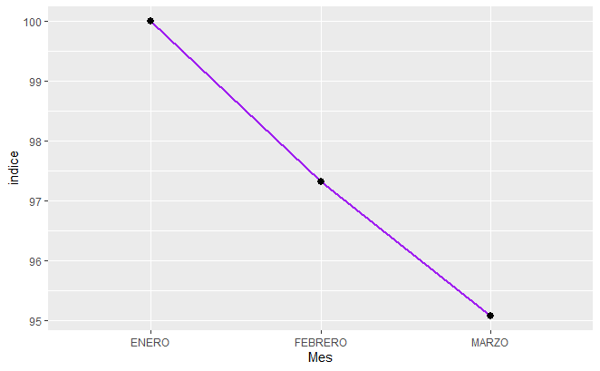

```r
#se grafican los datos del indice general
grafica(resipp, 'Mes', 'indice')
```

### 1.5 Calculo de Incidencias

Calcula las incidencias de los indices de los productos utilizando la funcion ‘incidencias’

```r
indgen_ant <- as.data.frame(readind(mesant, mesant)) #se importan los indices del mes anterior

incid <- incidencias(ind_prod01)
```

```r
incid %>% filter(incid < 0)
```

| PRODUCTO | indact | ponderacion | indant | incid |
| --- | --- | --- | --- | --- |
| C101011 | 99.35073 | 2.36777259 | 101.01155 | -4.040957e-02 |
| C101041 | 89.36430 | 0.96039883 | 89.44054 | -7.523965e-04 |
| C102012 | 0.00000 | 0.32918730 | 97.61284 | -3.301950e-01 |
| C103014 | 99.90602 | 0.48265520 | 99.94050 | -1.710205e-04 |
| C104012 | 97.72919 | 0.23999963 | 98.04749 | -7.850056e-04 |
| C104013 | 0.00000 | 0.90720114 | 99.22354 | -9.249936e-01 |
| C105011 | 99.25577 | 0.45665550 | 99.98765 | -3.434364e-03 |
| C106131 | 99.55192 | 0.75063673 | 99.83978 | -2.220397e-03 |
| C106211 | 99.98367 | 0.10955760 | 99.99188 | -9.248786e-06 |
| C107211 | 99.74843 | 2.65408875 | 100.13392 | -1.051376e-02 |

[output cut: 25 more lines]

```r
incid %>% filter(incid > 0)
```

| PRODUCTO | indact | ponderacion | indant | incid |
| --- | --- | --- | --- | --- |
| C101021 | 97.14388 | 0.57749816 | 96.49069 | 3.876285e-03 |
| C102011 | 107.15297 | 0.32626320 | 103.71838 | 1.151502e-02 |
| C103011 | 101.43840 | 0.62898487 | 100.00000 | 9.296964e-03 |
| C103012 | 101.17711 | 0.10696650 | 100.47201 | 7.750271e-04 |
| C103013 | 100.23066 | 0.54914562 | 99.94994 | 1.584134e-03 |
| C104011 | 102.72842 | 3.20171280 | 100.28680 | 8.033056e-02 |
| C105012 | 99.46097 | 1.11391788 | 99.35043 | 1.265290e-03 |
| C106111 | 96.67845 | 0.73164131 | 96.67704 | 1.056199e-05 |
| C107511 | 100.98704 | 0.22953814 | 100.00000 | 2.328135e-03 |
| C107911 | 101.10989 | 3.56459582 | 100.04749 | 3.891491e-02 |

[output cut: 13 more lines]

```r
incid %>% select(incid) %>%
  summarize(total = sum(incid))
```

| total |
| --- |
| -2.194224 |

```r
ind$indice/indgen_ant$indice*100-100
```

```
[1] -2.300776
```

### 1.6 Outliers

Se realizo un analisis inicial para determinar outliers en el grupo de datos de los relativos de las variedades.

#### 1.6.1 Resumen estadisticos

Primero obtuve los datos estadisticos de los relativos de los precios, para poder tener una noción de la distribucion de los precios, y poder determinar la mejor metodologia para obtener outliers

```r
summary(relativo_var$rel_var)
```

```
   Min. 1st Qu.  Median    Mean 3rd Qu.    Max.
  0.000   1.000   1.000   1.003   1.000  10.000
```

A partir de los resultados se observa que los cuartiles 1 y 3 son iguales, por lo que no se podria hacer un analisis de cuartiles para poder determinar outliers. Entonces realice una prueba de normalidad para determinar la distribucion de los datos y a partir de ello determinar un metodo para outliers.

#### 1.6.2 Prueba de normalidad

Utilizo la prueba Anderson-Darling, con las siguientes hipotesis:

H0 -> la muestra proviene de una dist normal

H1 -> la muestra no proviene de una dist normal

```r
library('nortest')
library('moments')

ad.test(relativo_var$rel_var)
```

```
    Anderson-Darling normality test

data:  relativo_var$rel_var
A = 638.17, p-value < 2.2e-16
```

El valor de A es alto, lo cual indica que los datos se desvian de forma significativa d euna distribucion normal. El valor p es muy pequeño, por lo que la probabilidad de que los datos tengan una dist normal es muy baja. A partir de esto se rechazaria la hipotesisi nula, por lo que la muestra no proviene de una dist normal.

Ya que se conoce esto, entonces se debe hacer un analisis de outliers para muestras que no siguen la dist normal.

#### 1.6.3 Analisis de valores extremos

En este caso opte por un analisis de valores extremos, usando como limite inferior un 0.5% y limite superior 99.5%.

```r
outliers <- which(relativo_var$rel_var < quantile(relativo_var$rel_var, 0.005) | relativo_var$rel_var > quantile(relativo_var$rel_var, 0.995))
relativo_var[outliers, ]
```

| PRODUCTO | VARIEDAD | MARZO | FEBRERO | rel_var |
| --- | --- | --- | --- | --- |
| C141011 | C14101107 | 28.08515 | 39.65550 | 0.7082284 |
| C105011 | C10501102 | 12.10000 | 15.00000 | 0.8066667 |
| C161011 | C16101102 | 17.41000 | 10.98214 | 1.5853008 |
| C210011 | C21001106 | 10.00000 | 1.00000 | 10.0000000 |
| C239212 | C23921204 | 1804.00000 | 1473.00000 | 1.2247115 |
| C239212 | C23921204 | 10893.00000 | 8813.00000 | 1.2360150 |
| C101011 | C10101102 | 22.51000 | 28.23000 | 0.7973787 |
| C181111 | C18111102 | 0.13000 | 0.10000 | 1.3000000 |
| C181111 | C18111102 | 0.38000 | 0.31000 | 1.2258065 |
| C170911 | C17091107 | 49.38000 | 40.18000 | 1.2289696 |

[output cut: 10 more lines]

En este caso se obtienen 20 valores que se encuentra por debajo del 0.5% o por arriba del 99.5%, tanto para enero como febrero y marzo

#### 1.6.4 Histograma y box-plot

Tambien se puede hacer un analisis a partir de una box-plot, para determinar los outliers.

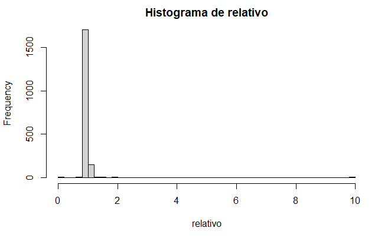

```r
hist(relativo_var$rel_var,
  xlab = "relativo",
  main = "Histograma de relativo",
  breaks = sqrt(length(relativo_var$rel_var)) # set number of bins
)
```

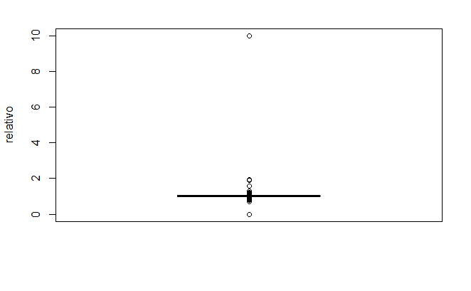

```r
boxplot(relativo_var$rel_var,
  ylab = "relativo"
)
```

```r
outliers_box <- which(relativo_var$rel_var %in% boxplot.stats(relativo_var$rel_var)$out)
relativo_var[outliers_box, ]
```

| PRODUCTO | VARIEDAD | MARZO | FEBRERO | rel_var |
| --- | --- | --- | --- | --- |
| C162111 | C16211102 | 2.421789e+03 | 2.708615e+03 | 0.8941061 |
| C162111 | C16211102 | 2.664015e+03 | 2.979523e+03 | 0.8941078 |
| C162111 | C16211102 | 3.786544e+03 | 4.235013e+03 | 0.8941043 |
| C162111 | C16211102 | 4.165143e+03 | 4.658405e+03 | 0.8941136 |
| C162111 | C16211102 | 4.966604e+03 | 5.554793e+03 | 0.8941114 |
| C162111 | C16211102 | 5.463233e+03 | 6.110280e+03 | 0.8941051 |
| C110411 | C11041101 | 1.168915e+00 | 1.171911e+00 | 0.9974439 |
| C110411 | C11041101 | 1.948192e+00 | 1.953185e+00 | 0.9974439 |
| C103013 | C10301301 | 1.870265e+00 | 1.875058e+00 | 0.9974439 |
| C110412 | C11041202 | 4.675662e-01 | 4.687644e-01 | 0.9974439 |

[output cut: 373 more lines]

En estee caso, a partir de la box-plot se encuentran 214 valores que serian outliers (para enero).

En el caso de Febrero son 361 outliers, y marzo son 383 outliers

## 2. Revision de productos faltantes

Se obtienen los articulos de los que no se obtuvo informacion cada mes, para ello se importann los datos faltantes imputados y no imputados para cada mes con la función ‘count_imput’, dicha función asigna el valor 1 si el precio NO se registro en ese mes y el valor 0 si en ese mes SI se registro precio.

```r
resultados <- count_imput()

#se guardan los resultados en dos datafrmaes, separando los datos faltantes en imputados y los no imputados
count_imputables <- resultados$imputados
count_noimputables <- resultados$noimputados
```

Revisa las variedades que no han presentado precios en tres o mas meses de las variedades que si pueden imputarse

```r
count_imputables %>% filter(total >= 3)
```

| VARIEDAD | ENERO | FEBRERO | MARZO | total |
| --- | --- | --- | --- | --- |
| C10711205 | 1 | 1 | 1 | 3 |
| C10611102 | 1 | 1 | 1 | 3 |
| C11011102 | 1 | 1 | 1 | 3 |
| C22201103 | 1 | 1 | 1 | 3 |
| C22201104 | 1 | 1 | 1 | 3 |
| C17091101 | 1 | 1 | 1 | 3 |
| C17091102 | 1 | 1 | 1 | 3 |
| C17091103 | 1 | 1 | 1 | 3 |
| C20112109 | 1 | 1 | 1 | 3 |
| C10301406 | 1 | 1 | 1 | 3 |

[output cut: 15 more lines]

```r
#test
```

Revisa las variedades que no han presentado precios en tres o mas meses de las variedades que no pueden imputarse

```r
count_noimputables %>% filter(total >= 3)
```

| VARIEDAD | ENERO | FEBRERO | MARZO | total |
| --- | --- | --- | --- | --- |
| C11031101 | 1 | 1 | 1 | 3 |
| C32501101 | 1 | 1 | 1 | 3 |
| C10201201 | 1 | 1 | 1 | 3 |
| C25121101 | 1 | 1 | 1 | 3 |
| C29201101 | 1 | 1 | 1 | 3 |
| C11041201 | 1 | 1 | 1 | 3 |
| C10612101 | 1 | 1 | 1 | 3 |
| C13991101 | 1 | 1 | 1 | 3 |
| C17021201 | 1 | 1 | 1 | 3 |
| C23941101 | 1 | 1 | 1 | 3 |

[output cut: 3 more lines]

```r
#test1
```

Agrega las descripciones de las variedades a los resultados obtenidos

```r
pond_variedad <- ponderaciones %>% filter(CCP...1 == 'VARIEDAD') %>%
  select(PRODUCTO, DESCRIPCION) %>%
  rename('VARIEDAD' = PRODUCTO)
count_imputables1 <- count_imputables %>% left_join(pond_variedad) %>%
  select(VARIEDAD, DESCRIPCION, everything())
count_noimputables1 <- count_noimputables %>% left_join(pond_variedad) %>%
  select(VARIEDAD, DESCRIPCION, everything())
```

Guatda los resultados en un archivo de excel

```r
wb <- createWorkbook()

addWorksheet(wb, "imputables")
writeData(wb, "imputables", count_imputables1)

addWorksheet(wb, "no_imputables")
writeData(wb, "no_imputables", count_noimputables1)

file_name <- paste0("resumen_preciosfaltantes.xlsx")
saveWorkbook(wb, file_name, overwrite = TRUE)
```

Revisamos los productos que no aparecen

```r
#se obtienen los productos que no aparecen en el mes de calculo, esto debido a falta de precios en las variedades que los conforman
ponderaciones %>% filter(CCP...1 == 'PRODUCTO') %>% anti_join(ind_prod01) %>%
  select(CCP...1, PRODUCTO, DESCRIPCION, ponderacion) #%>%
```

| CCP...1 | PRODUCTO | DESCRIPCION | ponderacion |
| --- | --- | --- | --- |
| PRODUCTO | C107212 | Melaza | 0.38993153 |
| PRODUCTO | C139111 | Otros productos textiles (artículos textiles excepto prendas de vestir) | 0.77072100 |
| PRODUCTO | C141012 | Desperdicio o desecho de productos textiles y ropa usada | 0.01714685 |
| PRODUCTO | C151211 | Artículos de cuero | 0.24548316 |
| PRODUCTO | C242012 | Productos primarios de metales preciosos y otros metales no ferrosos | 0.45470260 |
| PRODUCTO | C272011 | Maquinaria y aparatos eléctricos, partes y piezas | 1.44751592 |
| PRODUCTO | C282111 | Maquinaria agricola y usos especiales | 0.41413889 |
| PRODUCTO | C282611 | Maquinaria para uso textil | 0.89147892 |

```r
  #summarize(total = sum(ponderacion))
```

```r
ponderaciones %>% filter(CCP...1 == 'PRODUCTO') %>%
  summarize(total = sum(ponderacion))
```

| total |
| --- |
| 100 |